# Report Example

# Executive Summary

# Business Objective

*What is the business goal we are trying to achieve?*

Our goal is to better plan our marketing initiatives and increase accountability among our stakeholders.

# Question

*What question(s) will we try to answer?*

Was last week a success or failure for our paid search (cpc) channel?

# Answer

# Insights

*A summary of any insights with visualizations.*

## Forecast vs Actual

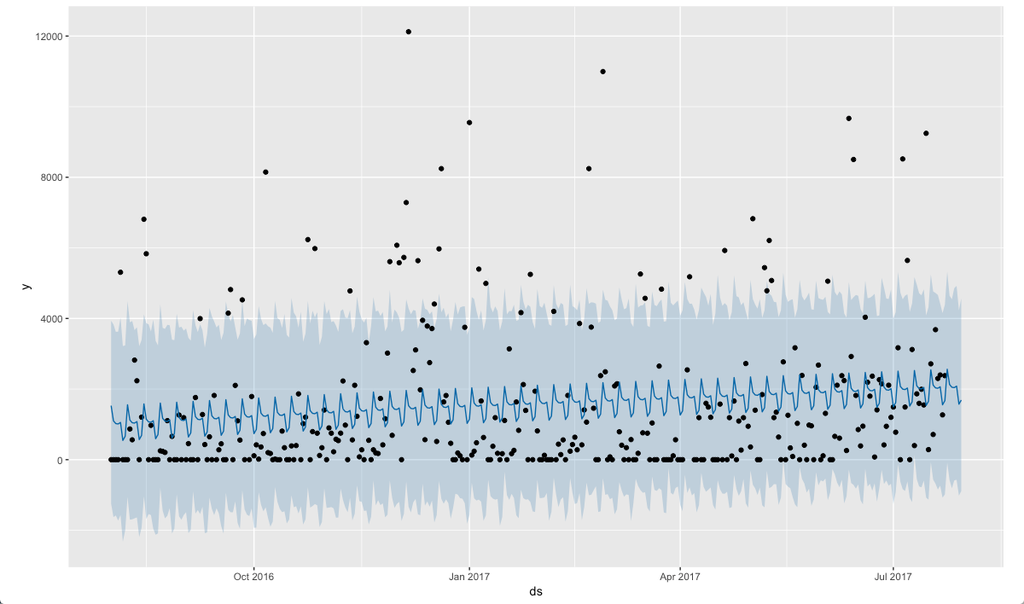

# Actions

*A list of recommended actions to take with the insights*

- Dig deeper to investigate question like “why did revenue generated from paid search (cpc) exceed our forecast so greatly?”
- Marketing mix modeling analysis to understand how much each marketing channel contributes to revenue, and how much to spend on each marketing channel
- Reallocate paid search revenue across campaigns or to different channel (e.g. - Google Remarketing or email)

# Model Summary

*A high level summary of the model, features and any other relevant info outlined in the scope*

We used the [prophet](https://facebook.github.io/prophet/docs/installation.html) R package to create a forecasting model.

Finally, it’s likely that we can automate a solution that will generate additional incremental business value by delivering this forecasting model into a dashboard of choice (Data Studio, Tableau, Looker, other)